# Exercices_reproduction_plots

Paolo Crosetto

10/15/2021

## Reproducing plots

In each exercice, you will be given a static image of a plot. Your aim is to reproduce it as close as possible.

For each exercise, you will start with the raw data. Produce first a “basic” plot that has the same main idea, geom_, facet_, aes() than the target plot; then, by using scale_, coord_ and theme_ functions, try to tweak the plot to get your creation as near as possible to the target.

**Remember: it is not important if you don’t make it, the important is to try and to get your hands dirty and to code, code, code.**

Ready? go!

## Airline strikes

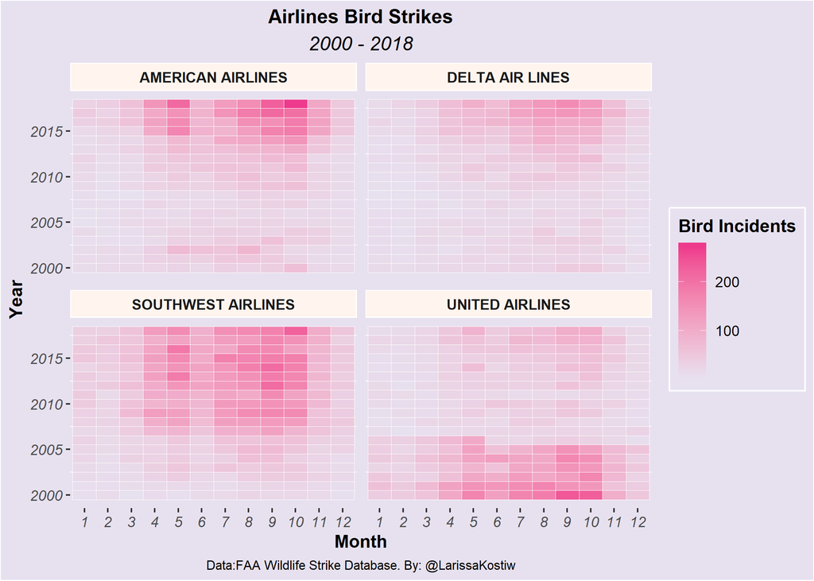

The data tells you all the times a plane has struck a bird in flight, for the US, for various years. Data is stored in the `strikes` data frame. Have a look at it, get familiar.

```r
strikes <- read_csv("https://raw.githubusercontent.com/rfordatascience/tidytuesday/master/data/2019/2019-07-23/wildlife_impacts.csv")
```

In a first chunk work on the **data**: use `filter`, `mutate`, `group_by`, `summarise`, `count` etc… to get the data you want. Think about what you *need* before you start coding. In this case, you need, for each airline, for each month and year, the *count* of incidents. Check that you got this right, then save it in an object of your choice (I usually use a name like `plotme` or `plotdf`.

```r
plotdf <- strikes %>%
  filter(incident_year >= 2000) %>%
  group_by(incident_month, incident_year, operator) %>%
  mutate(incident_month = as.factor(incident_month)) %>%
  tally()
plotdf
```

```
## # A tibble: 912 × 4
## # Groups:   incident_month, incident_year [228]
##    incident_month incident_year operator               n
##    <fct>                  <dbl> <chr>              <int>
##  1 1                       2000 AMERICAN AIRLINES     12
##  2 1                       2000 DELTA AIR LINES       15
##  3 1                       2000 SOUTHWEST AIRLINES     8
##  4 1                       2000 UNITED AIRLINES       41
##  5 1                       2001 AMERICAN AIRLINES     14
##  6 1                       2001 DELTA AIR LINES       12
##  7 1                       2001 SOUTHWEST AIRLINES     7
##  8 1                       2001 UNITED AIRLINES       64
##  9 1                       2002 AMERICAN AIRLINES     12
## 10 1                       2002 DELTA AIR LINES       11
## # … with 902 more rows
```

In a second chunk create a *simple* plot that has all the axes, geoms and facets needed. It will be ugly, but it will *work*: it shows the same relationship as the target plot. Here, you need to use a three-dimensional geom, where you have two categorical variables (month and year) and a third, continuous variable (the count of bird strikes). Look up in the *cheatsheet* or in the course notes which geom_ will do the trick. Use facets. Save the plot in a `base_plot` object (or other name of your choice).

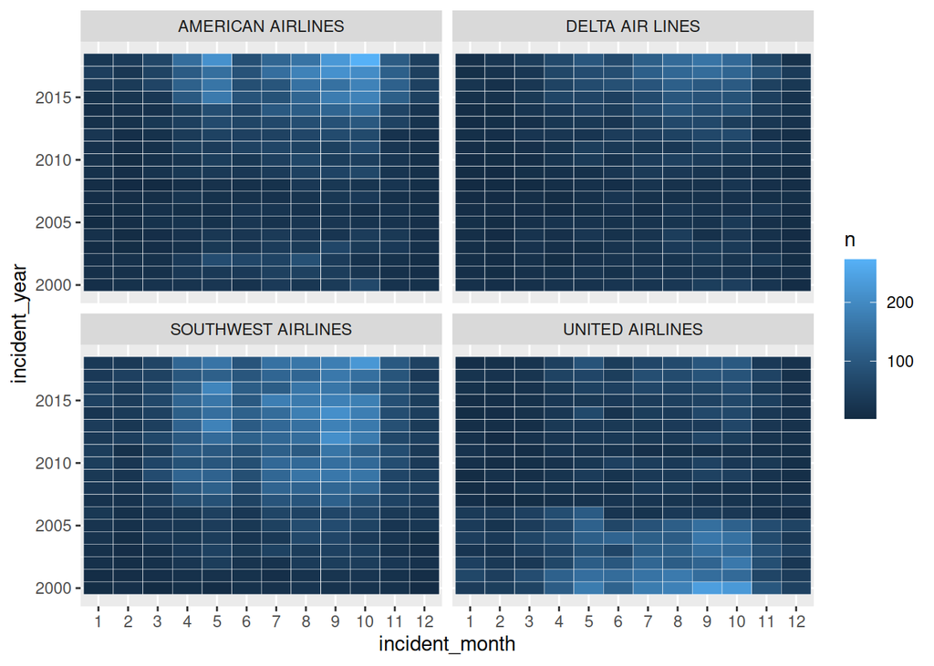

```r
base_plot <- plotdf %>%
  ggplot()+
  aes(x = incident_month, y = incident_year, fill = n)+
  geom_tile(color = "white")+
  facet_wrap(~operator)
base_plot
```

In a third chunk tweak the plot to look like the target. Get as near as you can. Use `scale_`, `theme_` functions; think of `coord_` and think of the nature of the variables; remember that you can turn a categorical variable into a numeric one by using `mutate(var = as.character(var))` and a categorical into numeric (if that is possible) using `mutate(var = as.numeric(var)`. That might turn out to be useful.

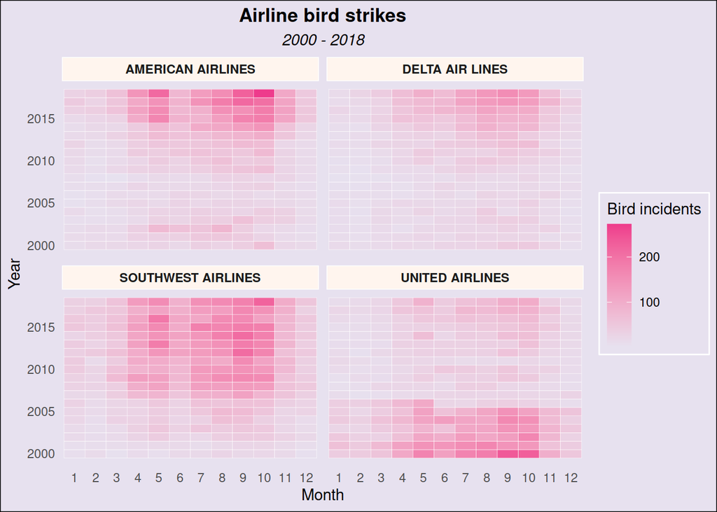

```r
base_plot +
  labs(x = "Month", y = "Year", title = "Airline bird strikes", subtitle = "2000 - 2018")+
  scale_fill_gradient(name = "Bird incidents", low = "#e7e1ef", high = "#ee3b8c")+
  theme_minimal()+
  theme(panel.grid = element_blank(),
        strip.background = element_rect(fill = "#fff5ee", linetype = 1, color = "white"),
        strip.text = element_text(face = "bold"),
        legend.background = element_rect(linetype = 1, fill = "#e7e1ef", color = "white"),
        plot.background = element_rect(fill = "#e7e1ef"),
        plot.title = element_text(face = "bold", hjust = 0.5),
        plot.subtitle = element_text(face = "italic", hjust = 0.5))
```

## Big Mac Index

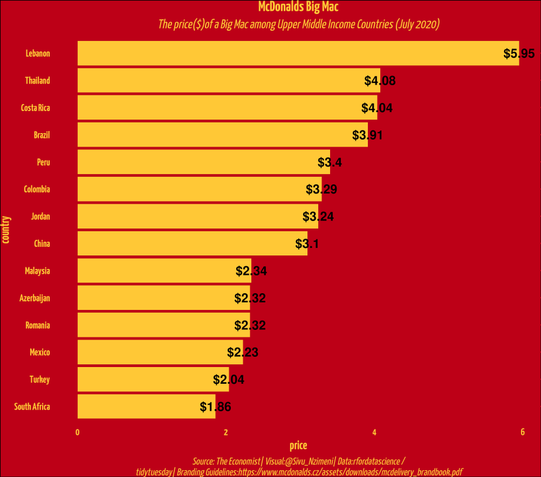

The data tells you the cost of a big mac in time for different countries. The Big Mac index is used sometimes to compare countries for their purchasing power; since a Big Mac is a Big Mac (i.e. virtually identical) anywhere, its price tells you something about the relative prices in different countries and inflation (i.e. price changes in time).

The data, saved in `bigmac` object:

```r
bigmac <- read_csv('https://raw.githubusercontent.com/rfordatascience/tidytuesday/master/data/2020/2020-12-22/big-mac.csv')
```

A chunk for data manipulation. For this plot, you need to restrict attention to Upper Middle Income countries, and to July 2020 only.

```r
plotme <- bigmac %>%
  filter(date == "2020-07-01") %>%
  filter(name %in% c("Lebanon", "Thailand", "Costa Rica", "Brazil", "Peru", "Colombia",
                     "Jordan", "China", "Malaysia", "Azerbaijan", "Romania", "Mexico",
                     "Turkey", "South Africa")) %>%
  select(name, dollar_price)
```

A chunk for the basic plot without styling: note that here you can use `geom_text` to put the dollar amounts on the bars. Check the course slides for L5, we did not cover that in class but we do have some stuff at the end on `geom_text`.

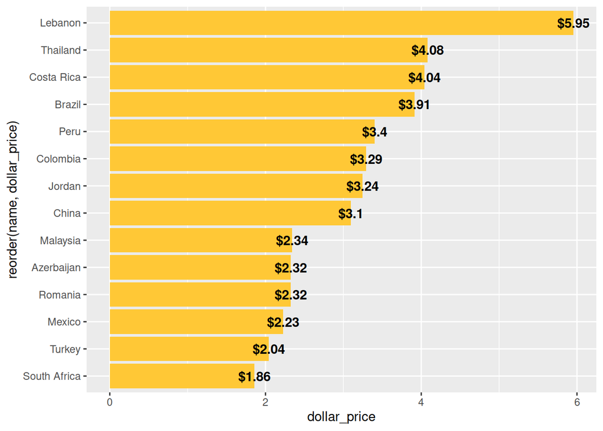

```r
base_plot <- plotme %>%
  ggplot(aes(x = dollar_price, y = reorder(name, dollar_price)))+
  geom_col(fill = "#ffc836")+
  geom_text(aes(label = paste0("$",round(dollar_price,2))), fontface = "bold")
base_plot
```

A chunk for the style and the final plot. Note that this is not a particularly pretty plot, but it manipulates lots of things. Remember that within the `theme` call you can `tab` to search the various items you can change, and then you must change the `element_*` corresponding to what you want to change. Google around or look at the code from the lecture to get a feel of it.

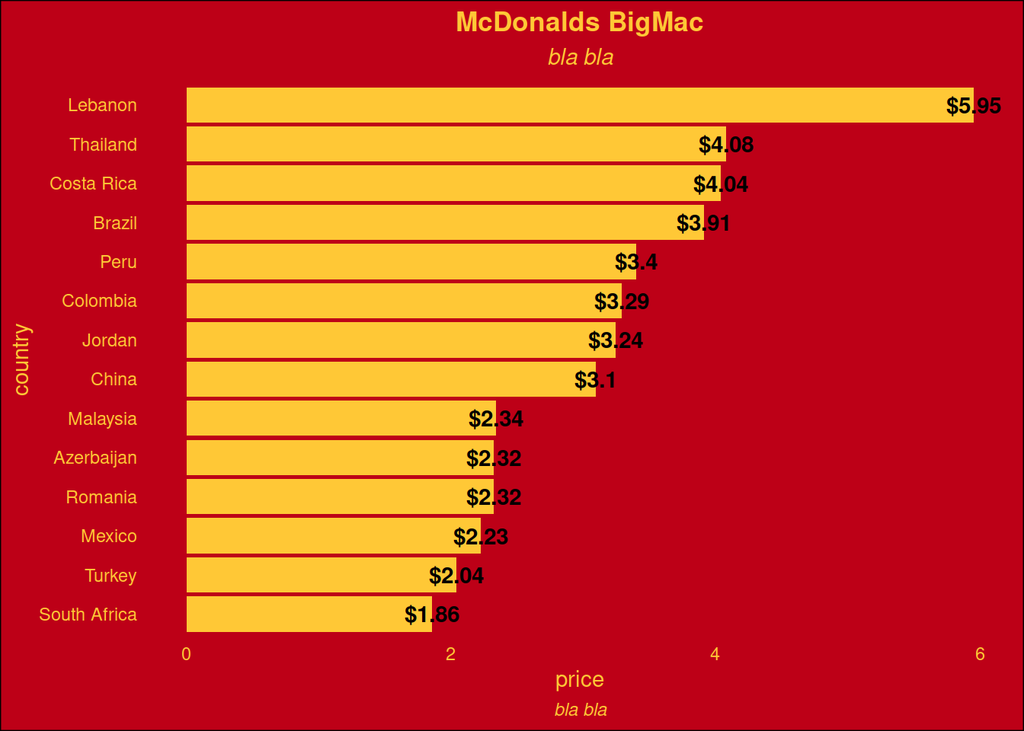

```r
base_plot +
  theme_minimal()+
  theme(panel.grid = element_blank(),
        plot.background = element_rect(fill = "#bd0017"),
        axis.title = element_text(color = "#ffc836"),
        axis.text = element_text(color = "#ffc836"),
        plot.title = element_text(color = "#ffc836", hjust = 0.5, face = "bold"),
        plot.subtitle = element_text(color = "#ffc836", hjust = 0.5, face = "italic"),
        plot.caption = element_text(color = "#ffc836", hjust = 0.5, face = "italic"))+
  labs(y = "country", x = "price", title = "McDonalds BigMac", subtitle = "bla bla", caption = "bla bla")
```

## K-pop

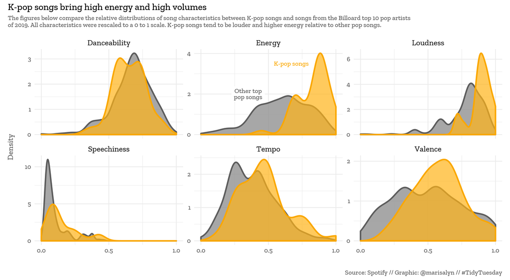

Data shows music genres and music characteristics from the Spotify database.

```r
spotify <- readr::read_csv('https://raw.githubusercontent.com/rfordatascience/tidytuesday/master/data/2020/2020-01-21/spotify_songs.csv')
```

In this case I’ll help you out a bit and generate a `kpop` and `billboard` variables to get you started.

```r
kpop <- c(
  "bts",
  "blackpink",
  "twice",
  "広瀬大地", # "exo"
  "red velvet",
  "seventeen",
  "stray kids",
  "nct 127",
  "ikon",
  "got7")
# https://www.billboard.com/charts/year-end/pop-songs-artists
# billoard top 10 pop artists of 2019
other_pop <- c(
  "ariana grande",
  "post malone",
  "khalid",
  "jonas brothers",
  "halsey",
  "panic! at the disco",
  "shawn mendes",
  "billie eilish",
  "lizzo",
  "ed sheeran" )

df <- spotify %>%
  filter(tolower(track_artist) %in% c(tolower(kpop), tolower(other_pop))) %>%
  mutate(kpop = if_else(tolower(track_artist) %in% tolower(kpop),
                        1, 0),
         kpop = factor(kpop))
```

Now you need to tidy your dataset, until you’ll get a dataset with a row for each characteristic of each song (Danceability, Energy, …). Do it in this chunk here:

```r
plotme <- df %>%
  select(track_id, kpop, danceability, energy, loudness, speechiness, tempo, valence) %>%
  pivot_longer(-track_id & -kpop, names_to = "characteristic", values_to = "value")
plotme
```

```
## # A tibble: 2,700 × 4
##    track_id               kpop  characteristic    value
##    <chr>                  <fct> <chr>             <dbl>
##  1 6f807x0ima9a1j3VPbc7VN 0     danceability     0.748
##  2 6f807x0ima9a1j3VPbc7VN 0     energy           0.916
##  3 6f807x0ima9a1j3VPbc7VN 0     loudness        -2.63
##  4 6f807x0ima9a1j3VPbc7VN 0     speechiness      0.0583
##  5 6f807x0ima9a1j3VPbc7VN 0     tempo          122.
##  6 6f807x0ima9a1j3VPbc7VN 0     valence          0.518
##  7 7fvUMiyapMsRRxr07cU8Ef 0     danceability     0.675
##  8 7fvUMiyapMsRRxr07cU8Ef 0     energy           0.919
##  9 7fvUMiyapMsRRxr07cU8Ef 0     loudness        -5.38
## 10 7fvUMiyapMsRRxr07cU8Ef 0     speechiness      0.127
## # … with 2,690 more rows
```

Now time for a not-so fancy plot: this should just be a matter of `geom_density` and `facet`ing.

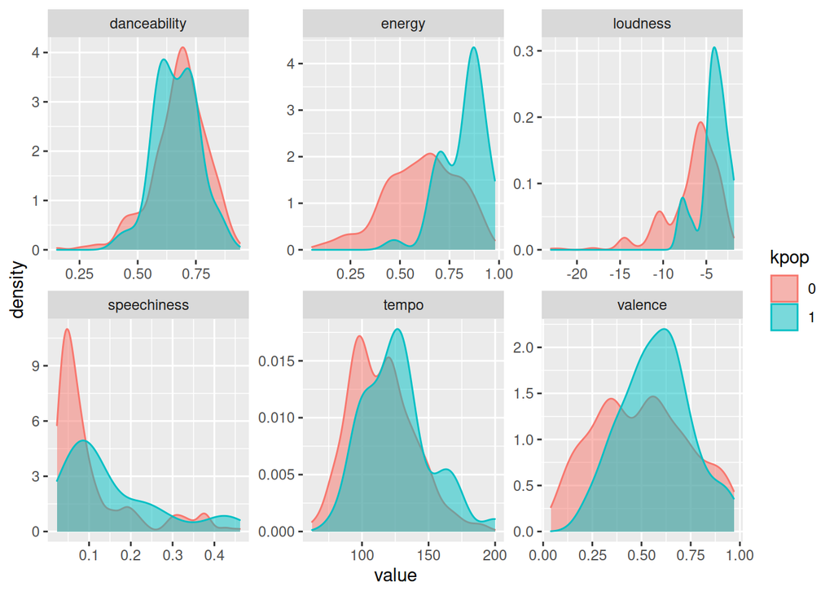

```r
base_plot <- plotme %>%
  ggplot(aes(value, color = kpop, fill = kpop))+
  geom_density(alpha = 0.5)+
  facet_wrap(~characteristic, scales = "free")
base_plot
```

And now, make it fancy!

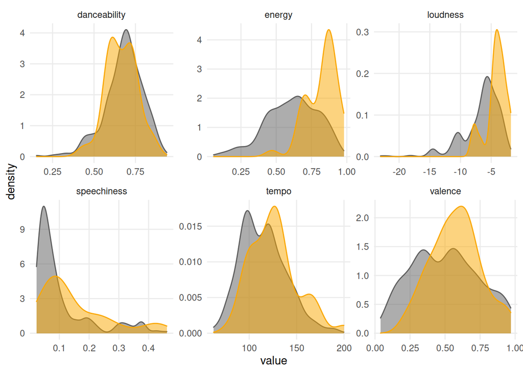

```r
base_plot +
  scale_color_manual(values = c("#5c5c5c", "#faa700"))+
  scale_fill_manual(values = c("#5c5c5c", "#faa700"))+
  theme_minimal()+
  theme(legend.position = "none",
        panel.grid.minor = element_blank())
```